# Communicating Data Findings (Ford GoBike System Data)

## 4- Number of Trips Bades on Gender of Bike Users

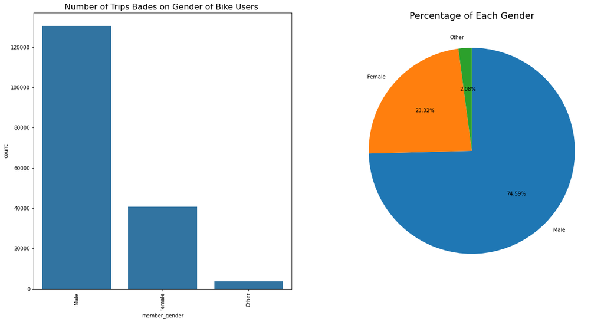

```python
#plot a side by side bar and pie chart for member_gender
bar_pie('member_gender', 'Number of Trips Bades on Gender of Bike Users ', 'Percentage of Each Gender')
```

> The number of male users was higher by more than 120,000 trips (almost 75%)

## 5- Top 10 Popular Start & End Stations in Term of Trips Number

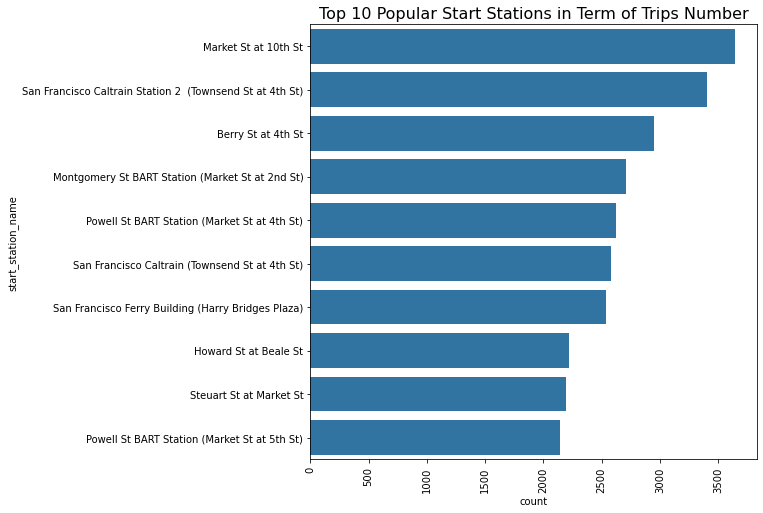

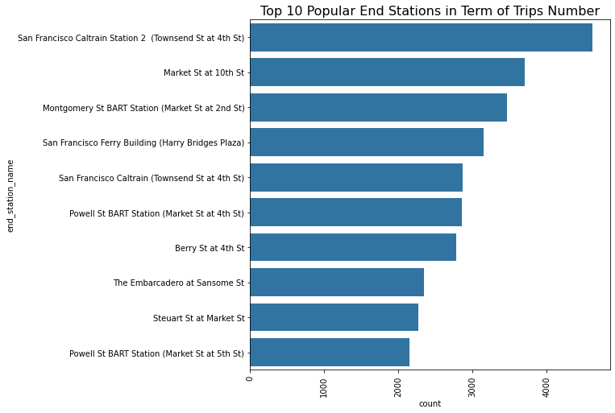

```python
def popular(col, title):
    ''' This function is to create bar chart with only top 10 values'''
    plt.figure(figsize=(8,8))
    order = df[col].value_counts().head(10).index
    base_color = sb.color_palette()[0]
    sb.countplot(data = df, y = col, color = base_color, order = order);
    plt.xticks(rotation = 90);
    plt.title(title, size = 16);


#plot bar chart to visualize the top 10 start & end stations
popular('start_station_name', 'Top 10 Popular Start Stations in Term of Trips Number')
popular('end_station_name', 'Top 10 Popular End Stations in Term of Trips Number')
```

> The most two popular start and end stations is `Market St at 10th St` and `San Francisco Caltrain Station 2 (Townsend St at 4th St)`.

## 6 - Distribution of Bike Trips Duration in Minutes

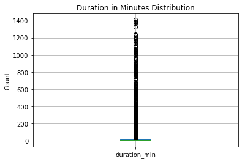

```python
def box_plot(col, title):
    ''' This function is to create a boxplot for one cloumn'''
    dur_min= df.boxplot(column= col)
    dur_min.set_ylabel('Count')
    dur_min.set_title(title);

#visualize the distribution of duration in minutes with boxplot
box_plot('duration_min','Duration in Minutes Distribution')
```

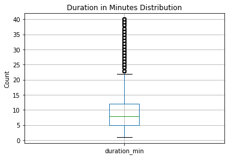

```python
def drop_outliers(col, value):
    '''This function is to drop the outliers that found in the column'''
    df.drop(df[df[col] > value ].index, inplace = True)


#visualize the distribution of duration in minutes with boxplot after dropping outliers in duration_min column
drop_outliers('duration_min', 40)
box_plot('duration_min','Duration in Minutes Distribution')
```

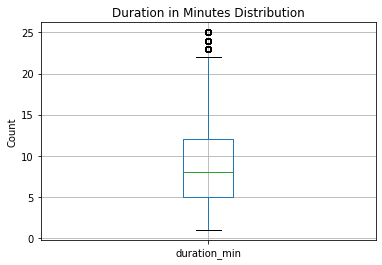

```python
#again dropping outliers and visualize with boxplot
drop_outliers('duration_min', 25)
box_plot('duration_min','Duration in Minutes Distribution')
```

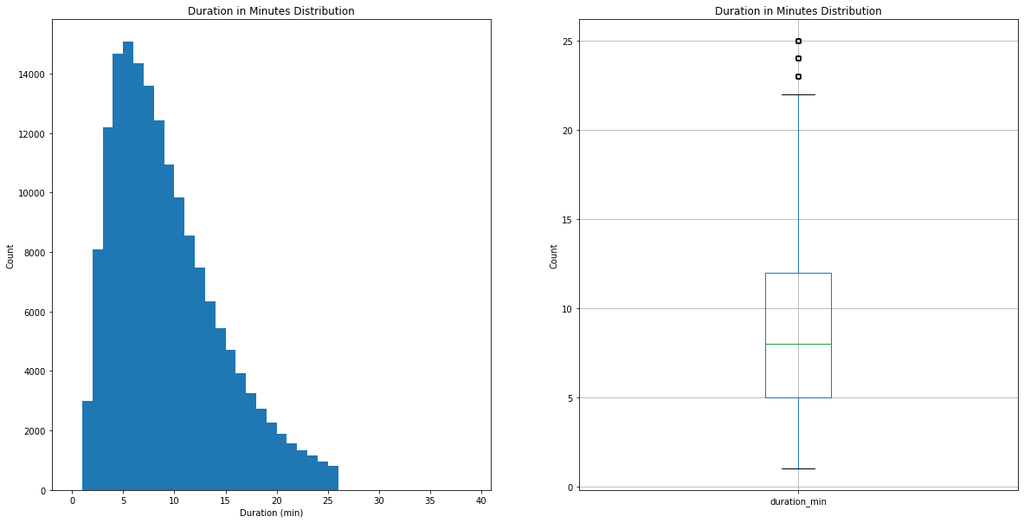

```python
#plot a histogram using `.hist` function and box plot with box_plot function
#that we created earlier for duration_min column
plt.figure(figsize=(20,10))

plt.subplot(1, 2, 1)
bins = np.arange(0, 40)

plt.hist(df.duration_min, bins= bins)
plt.xlabel('Duration (min)')
plt.ylabel('Count')
plt.title('Duration in Minutes Distribution');

plt.subplot(1, 2, 2)
box_plot('duration_min','Duration in Minutes Distribution')
```

> This distribution is `skewed right` and show that the **median** of trip duration is about `8 min`.

## 7 - Distribution of Bike Users Age

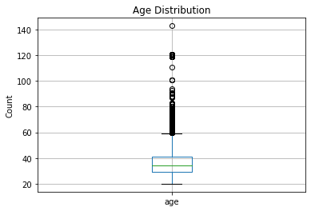

```python
#visualize the distribution of users age with boxplot
box_plot('age','Age Distribution')
```

```python
#drop outliers in age column
drop_outliers('age', 60)
```

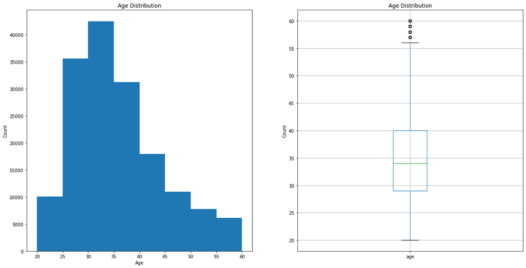

```python
#visualize the distribution of users age with boxplot after dropping outliers in the column
plt.figure(figsize=(20,10))

plt.subplot(1, 2, 1)
bins = np.arange(20, 65, 5)
plt.hist(df.age , bins= bins)
plt.xlabel('Age')
plt.ylabel('Count')
plt.title('Age Distribution')


plt.subplot(1, 2, 2)
box_plot('age','Age Distribution')
```

> This distribution is `skewed right` and show that the **median** of users age is about `34 years`. The boxplot show that the age range is between `20 - 56 years`.

### Discuss the distribution(s) of your variable(s) of interest. Were there any unusual points? Did you need to perform any transformations?

There were an outliers in `age` and `duration_min` variables and I didn't perform any transformations.

### Of the features you investigated, were there any unusual distributions? Did you perform any operations on the data to tidy, adjust, or change the form of the data? If so, why did you do this?

I removed the outliers that found in both `age` and `duration_min` variables.